# MLSP ASSIGNMENT 1

# P1: MLE for uniform distribution [3 points]

1. The total scores from the results of survey  
   92,95.8,91.3,94.1,90.9

```python
import numpy as np
import matplotlib.pyplot as plt

from scipy.stats import uniform
```

The point here is to find the a,b values which helps in maximizing the likelihood of finding the observed 5 values. The probability of finding any value under a distribution is represented by the area under the curve. The area under the curve is usually calculated by integrating the f(x) with a,b as limits but in uniform distribution its just the area of the rectangle.

If 'a' is greater than minimum of observations, then the likelihood is 0 or If 'b' is lesser than the maximum of the observations, then the likelihood is 0. This is because in both the cases you'll have the observations lying outside [a,b] leading to probability 0. In both the cases denominator 'b-a' gets bigger reducing the area under the curve implying less likelihood when compared to b= max(data) a=min(data)

To maximize the likelihood of finding the data in the the 'a' value must be the smallest value in the data, 'b' should be the largest element in the data. a= 90.9 b= 95.8

```python
data= [92,95.8,91.3,94.1,90.9]
a=90.9
b=95.8
data = np.random.uniform(90.9,95.8,1000)# generating random data points within the given range of values to plot the uniform dist
rv = uniform (a, b) # a uniform dist is charecterised by its extreme values i.e, the bounds of x where f(X)=1/(b-a)
```

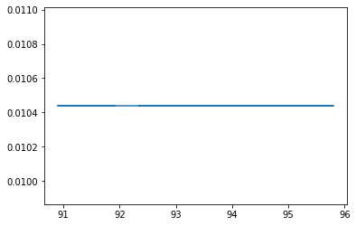

```python
plt.plot(data, rv.pdf(data))
```

```python
data= [92,95.8,91.3,94.1,90.9]
a=90
b=100
data = np.random.uniform(90,95,1000)
rv = uniform (a, b)
```

- Considering that A+ is not the best grade and there could be a better grade than that.

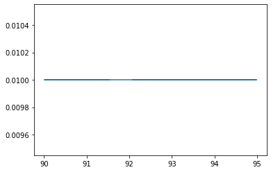

```python
plt.plot(data, rv.pdf(data))
```

# P2: Central Limit Theorem [3 points]

```python
import numpy as np
import matplotlib.pyplot as plt
import scipy.io as sio
import cv2
import scipy
```

```python
image1=cv2.imread('luddy1.jpeg')
image2=cv2.imread('luddy2.jpeg')
image3=cv2.imread('luddy3.jpeg')
```

```python
image1 = np.asarray(image1)
image2 = np.asarray(image2)
image3 = np.asarray(image3)
```

```python
image1=image1.reshape(-1,1)
image3=image3.reshape(-1,1)
image2=image2.reshape(-1,1)
```

```
<function matplotlib.pyplot.show(*args, **kw)>
```

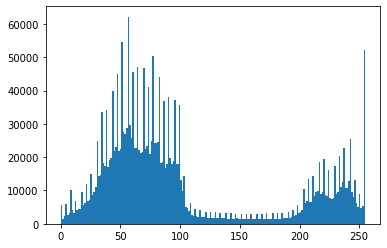

```python
plt.hist(x=image1, bins='auto')
plt.show
```

```
<function matplotlib.pyplot.show(*args, **kw)>
```

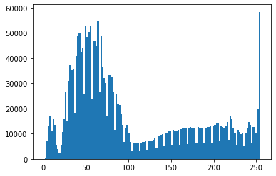

```python
plt.hist(x=image2, bins='auto')
plt.show
```

```
<function matplotlib.pyplot.show(*args, **kw)>
```

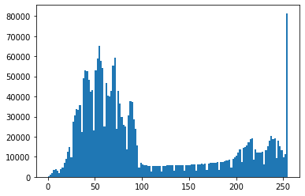

```python
plt.hist(x=image3, bins='auto')
plt.show
```

```python
image1 = (image1-np.mean(image1))/np.std(image1)
image2 = (image2-np.mean(image2))/np.std(image2)
image3 = (image3-np.mean(image3))/np.std(image3)
```

```python
def kurtosis(image):
  out=image**4-3
  return np.mean(out)
```

```python
kurtosis(image1)
```

```
-0.5591356613463501
```

```python
kurtosis(image2)
```

```
-0.9185331246099326
```

```python
kurtosis(image3)
```

```
-0.8409530035538864
```

kurtosis is the non-Gausianity metric. Visually the histogram of the first image seems less gaussian where as image 2 and image 3 histograms look more gaussian.

This is also supported by the the kurtosis value. Higher the kurtosis value lower the gaussian and lower the blurriness. Based on this the image 1 has the highest kurtosis value leading to be least gaussian there by less blurry than the other two. Based on the kurtosis values and histograms image 1 seems the sharpest one and the image 2 seems the blurriest one.

# P3: Gradient Ascent for Eigendecomposition [5 points]

```python
X = sio.loadmat('X.mat')
```

```python
X=X['X']
```

```python
X.shape
```

```
(2, 1000)
```

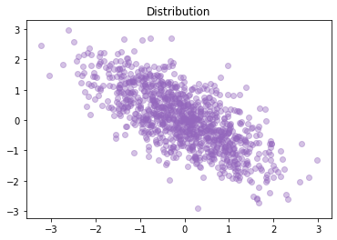

```python
plt.scatter(X[0],X[1],c ='#9467bd',alpha=.4)
plt.title('Distribution')
```

```python
w1 = np.random.standard_normal(2)
```

```python
w1=w1/np.linalg.norm(w1)
```

```python
z = np.dot(w1.T,X)
```

```python
ev1 = np.dot(z,z.T)
```

```python
ev1
```

```
1159.4125086405447
```

```python
ev1_updated=0
cond=np.absolute(ev1-ev1_updated)
```

```python
while (cond!=0):
    gradient = np.linalg.multi_dot([X,X.T,w1])
    w1=w1+0.01*gradient
    w1=w1/np.linalg.norm(w1)
    z= np.dot(w1.T,X)
    ev1_updated=ev1
    ev1 = np.dot(z,z.T)
    cond=np.absolute(ev1-ev1_updated)
    print(ev1)
```

```
1620.9245391507297
1656.6823585666589
1658.4942784966925
1658.5836950348366
1658.588101826685
1658.5883189962237
1658.5883296984437
1658.588330225854
1658.5883302518455
1658.5883302531256
1658.5883302531893
1658.588330253192
1658.5883302531925
1658.5883302531925
```

```python
print(w1)
```

```
[-0.70593278  0.70827884]
```

```python
v1=w1
v1=v1.reshape(2,1)
```

```python
v1
```

```
array([[-0.70593278],
       [ 0.70827884]])
```

```python
s1 = np.dot(v1.T,X)
```

```python
s1=np.linalg.norm(s1)
```

```python
s1
```

```
40.72576985464109
```

```python
u1 =np.dot(X.T,v1)/s1
```

```python
u1=u1.reshape(1000,1)
```

```python
temp=w1*s1
temp=temp.reshape(2,1)

X1= X-np.matmul(temp,u1.T)
```

```python
X1.shape
```

```
(2, 1000)
```

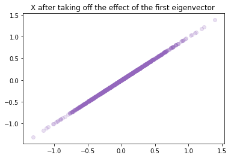

```python
plt.scatter(X1[0],X1[1],c ='#9467bd',alpha=0.2)
plt.title('X after taking off the eﬀect of the ﬁrst eigenvector ')
```

```python
w2 = np.random.standard_normal(2)
```

```python
w2=w2/np.linalg.norm(w2)
```

```python
z2 = np.dot(w2.T,X1)
```

```python
ev2 = np.dot(z2,z2.T)
```

```python
ev2
```

```
286.0707841530128
```

```python
ev2_updated=0
cond=np.absolute(ev2-ev2_updated)
```

```python
while cond>0:
    gradient1 = np.linalg.multi_dot([X1,X1.T,w2])
    w2=w2+0.01*gradient1
    w2=w2/np.linalg.norm(w2)
    z2= np.dot(w2.T,X1)
    ev2_updated=ev2
    ev2 = np.dot(z2,z2.T)
    cond=np.absolute(ev2-ev2_updated)

    print(ev2)
```

```
290.10508086978433
290.37376897147584
290.3914160816674
290.3925740546993
290.3926500343012
290.3926550196306
290.39265534673825
290.3926553682011
290.39265536960926
290.39265536970174
290.39265536970777
290.39265536970817
290.3926553697082
290.3926553697082
```

```python
v2=w2
v2=v2.reshape(2,1)
```

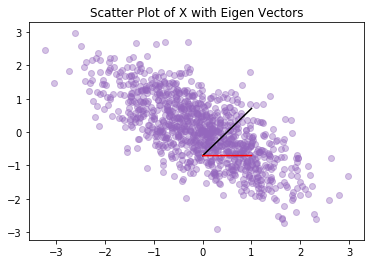

```python
plt.scatter(X[0],X[1],c ='#9467bd',alpha=0.4)
plt.plot(v1,color='black')
plt.plot(v2,color='red')
plt.title('Scatter Plot of X with Eigen Vectors')
plt.show()
```

```python
v1
```

```
array([[-0.70593278],
       [ 0.70827884]])
```

```python
v2
```

```
array([[-0.70827884],
       [-0.70593278]])
```

```python
v=np.column_stack((v1,v2))
```

```python
np.dot(v,v.T)#to check orthonormality of eigen vectors
```

```
array([[ 1.00000000e+00, -2.13513732e-12],
       [-2.13513732e-12,  9.99999999e-01]])
```

# P4: Eigenvectors for Two-Notes [4 points]

```python
data = sio.loadmat('flute.mat')
```

```python
X = data['X']
```

```python
X.shape
```

```
(128, 143)
```

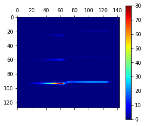

```python
plt.matshow(X,cmap='jet')
plt.colorbar()
```

```python
w1 = np.random.standard_normal(128)
```

```python
w1=w1/np.linalg.norm(w1)
```

```python
z = np.dot(w1.T,X)
```

```python
ev1 = np.dot(z,z.T)
```

```python
ev1
```

```
2172.9134483814337
```

```python
ev1_updated=0
cond=np.absolute(ev1-ev1_updated)
```

```python
while (cond!=0):
    gradient = np.linalg.multi_dot([X,X.T,w1])
    w1=w1+0.01*gradient
    w1=w1/np.linalg.norm(w1)
    z= np.dot(w1.T,X)
    ev1_updated=ev1
    ev1 = np.dot(z,z.T)
    cond=np.absolute(ev1-ev1_updated)
    print(ev1)
```

```
188066.4687419982
188623.759139225
188653.76432632693
188655.3874928857
188655.47528189555
188655.4800299136
188655.48028670723
188655.48030059575
188655.48030134695
188655.4803013876
188655.48030138976
188655.48030138985
188655.4803013899
188655.48030138985
188655.4803013899
188655.4803013899
```

```python
v1=w1
v1=v1.reshape(128,1)
```

```python
s1 = np.dot(v1.T,X)
s1=np.linalg.norm(s1)
```

```python
u1 =np.dot(X.T,v1)/s1
```

```python
u1=u1.reshape(143,1)
```

```python
temp=w1*s1
temp=temp.reshape(128,1)

X1= X-np.matmul(temp,u1.T) #removing effect of eigen vector 1
```

```python
X1.shape
```

```
(128, 143)
```

```python
w2 = np.random.standard_normal(128)
w2=w2/np.linalg.norm(w2)
```

```python
z2 = np.dot(w2.T,X1)
```

```python
ev2 = np.dot(z2,z2.T)
```

```python
ev2
```

```
5.077203209404761
```

```python
ev2_updated=0
cond=np.absolute(ev2-ev2_updated)
```

```python
while cond!=0:
    gradient1 = np.linalg.multi_dot([X1,X1.T,w2])
    w2=w2+0.01*gradient1
    w2=w2/np.linalg.norm(w2)
    z2= np.dot(w2.T,X1)
    ev2_updated=ev2
    ev2 = np.dot(z2,z2.T)
    cond=np.absolute(ev2-ev2_updated)

    print(ev2)
```

```
20660.99813341708
43796.711987100614
43797.070366927706
43797.07037080812
43797.07037080818
43797.070370808186
43797.070370808186
```

```python
v2=w2
v2=v2.reshape(128,1)
```

```python
v=np.column_stack((v1,v2))
```

```python
v.shape
```

```
(128, 2)
```

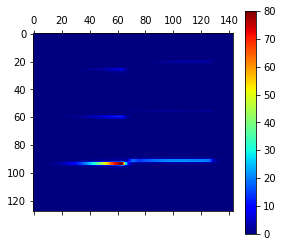

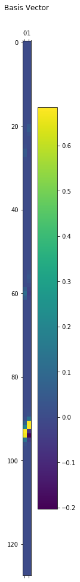

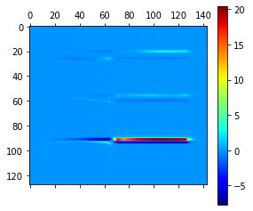

```python
plt.matshow(X,cmap='jet')
plt.colorbar()
plt.matshow(v)
plt.title('Basis Vector')
plt.colorbar()
plt.matshow(X1,cmap='jet')
plt.colorbar()
```

```python
activationv1=np.dot(v1.T,X)
```

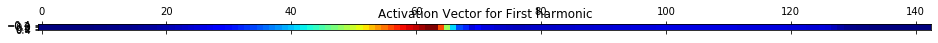

```python
plt.matshow(activationv1,cmap='jet')
plt.title('Activation Vector for First harmonic')
```

```python
activationv2=np.dot(v2.T,X)
```

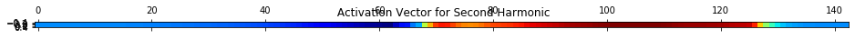

```python
plt.matshow(activationv2,cmap='jet')
plt.title(' Activation Vector for Second Harmonic')
```

```python
activationv=np.dot(v.T,X)
```

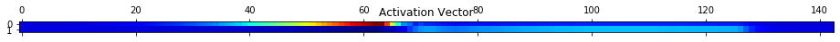

```python
plt.matshow(activationv,cmap='jet')
plt.title('Activation Vector')
```

```python
activationv.shape
```

```
(2, 143)
```

```python
harmonic1= np.dot(v1,activationv1)
```

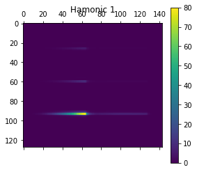

```python
plt.matshow(harmonic1)
plt.title('Hamonic 1')
plt.colorbar()
```

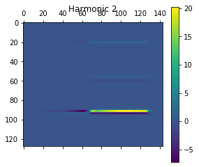

```python
harmonic2= np.dot(v2,activationv2)
plt.matshow(harmonic2)
plt.title('Harmonic 2')
plt.colorbar()
```

By projecting the data through the eigen vector we get the temporal activation matrix. Temporal activation = V.T*X

By projecting each eigen vector through the corresponding temporal activation vector we get the corresponding harmonics. Harmonic1= v1*activation1 Harmonic2= v2*activation2